# FinalReport

Devi States

April 24, 2019

## Introduction

### Importing data and libraries:

```r
library(gapminder)
library(plyr)
library(dplyr)
```

```r
library(tidyr)
library(corrplot)
library(lattice)
library(ggplot2)
library(purrr)
library(tidyverse)
library(cluster)
```

## Importing data as gapminder.csv file:

```r
library(readr)
gapdata<-read_csv("../Data/gapminder.csv")
```

## Discrption of data, data wrangling and data cleaning:

### Variables

1. country
2. continent
3. year
4. lifeExp life expectancy at birth
5. pop total population
6. gdpPercap per-capita

### Number of observations:

```r
nrow(gapminder)
```

```
## [1] 1704
```

### Number of variables

```r
ncol(gapminder)
```

```
## [1] 6
```

### Basic summary of statistics are shown below:

```r
summary(gapminder)
```

```
##         country        continent        year         lifeExp
##  Afghanistan:  12   Africa  :624   Min.   :1952   Min.   :23.60
##  Albania    :  12   Americas:300   1st Qu.:1966   1st Qu.:48.20
##  Algeria    :  12   Asia    :396   Median :1980   Median :60.71
##  Angola     :  12   Europe  :360   Mean   :1980   Mean   :59.47
##  Argentina  :  12   Oceania : 24   3rd Qu.:1993   3rd Qu.:70.85
##  Australia  :  12                  Max.   :2007   Max.   :82.60
##  (Other)    :1632
##       pop              gdpPercap
##  Min.   :6.001e+04   Min.   :   241.2
##  1st Qu.:2.794e+06   1st Qu.:  1202.1
##  Median :7.024e+06   Median :  3531.8
##  Mean   :2.960e+07   Mean   :  7215.3
##  3rd Qu.:1.959e+07   3rd Qu.:  9325.5
##  Max.   :1.319e+09   Max.   :113523.1
##
```

### There are not missing values

```r
sum(is.na(gapminder))
```

```
## [1] 0
```

### Type of variables

```r
lapply(gapminder, class)
```

```
## $country
## [1] "factor"
##
## $continent
## [1] "factor"
##
## $year
## [1] "integer"
##
## $lifeExp
## [1] "numeric"
##
## $pop
## [1] "integer"
##
## $gdpPercap
## [1] "numeric"
```

### The total number of countries in the data set is shown below::

```r
length(levels(gapminder$country))
```

```
## [1] 142
```

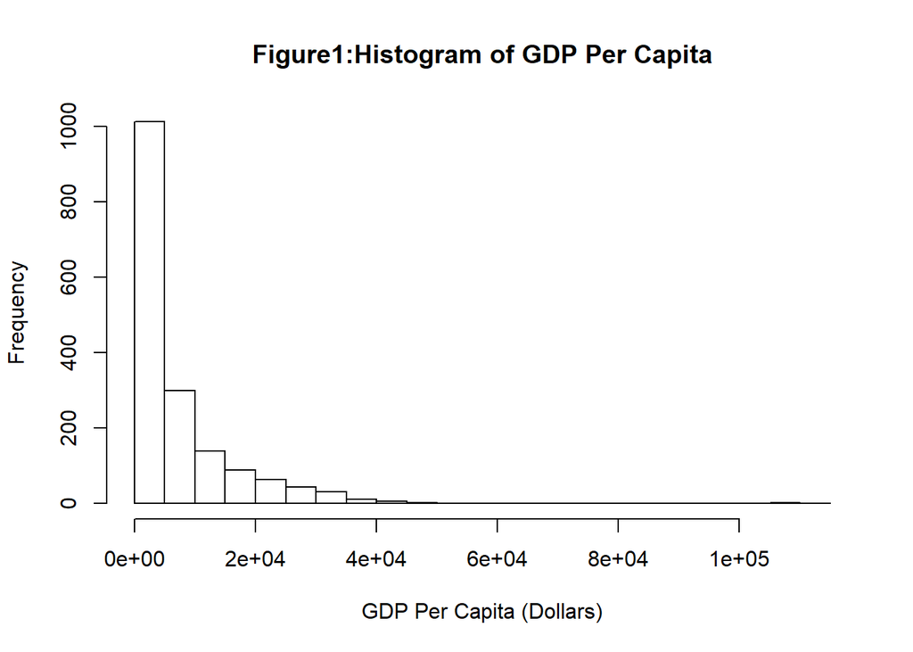

```r
hist(gapminder$gdpPercap,breaks = 30,main = "Figure1:Histogram of GDP Per Capita", xlab = "GDP Per Capita (Dollars)")
```

### The gapminder data frame range from 1952 to 2007

```r
range(gapminder$year)
```

```
## [1] 1952 2007
```

## Dta wrangling:

### The most ages ranges from 70.8 to 76.7 years old.

```r
gapminder$lifeExpcat <- cut(gapminder$lifeExp,breaks = 10)
table(gapminder$lifeExpcat)
```

```
##
## (23.5,29.5] (29.5,35.4] (35.4,41.3] (41.3,47.2] (47.2,53.1]   (53.1,59]
##           2          33         130         223         213         192
##   (59,64.9] (64.9,70.8] (70.8,76.7] (76.7,82.7]
##         187         293         320         111
```

### Preprocessing:

### Data transformation to normalize gdp

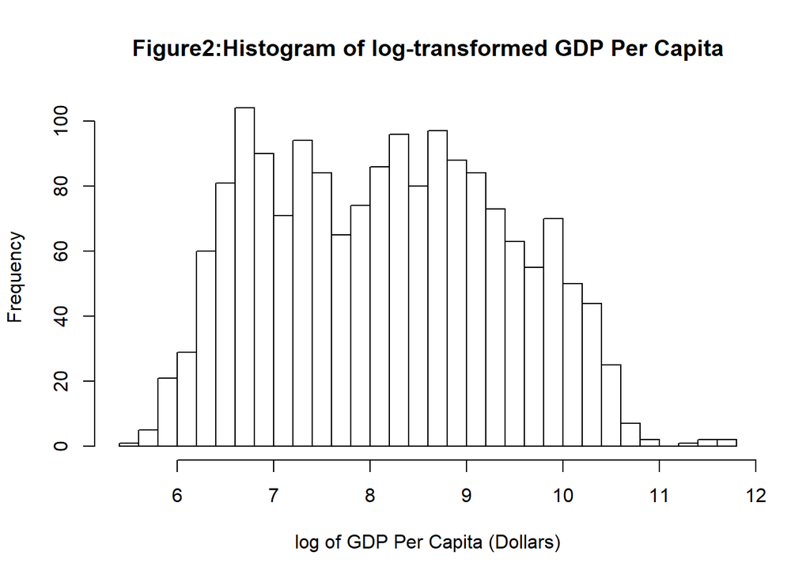

```r
gapminder$gdpPercaplog <- log(gapminder$gdpPercap)
hist(gapminder$gdpPercaplog,breaks = 30,main = "Figure2:Histogram of log-transformed GDP Per Capita", xlab = "log of GDP Per Capita (Dollars)")
```

## Exploring data:

[figure not shown]

```r
plot(lifeExp~gdpPercaplog,data = gapminder, main = "Figure-3: Life Expectancy and GDP for 2007",
xlab = "Log of GDP", ylab = "Years")
lifegdpmodel <- lm(lifeExp~gdpPercaplog,data = gapminder)
abline(lifegdpmodel, col = "red")
legend(x = "bottomright", lty = 1, col = "red", legend = "regression line")
```

```r
summary(lifegdpmodel)$r.squared
```

```
## [1] 0.6522466
```

### Research Question 2: What is life expectancy of different continent?

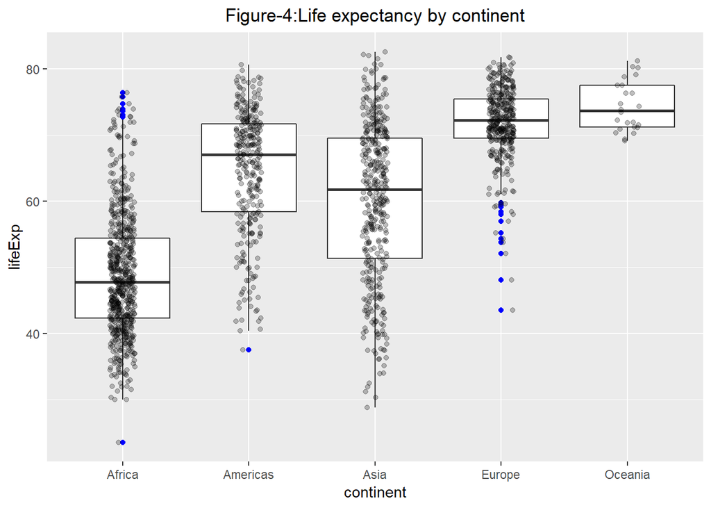

```r
ggplot(gapminder, aes(x = continent, y = lifeExp)) +
  geom_boxplot(outlier.colour = "blue") +
  geom_jitter(position = position_jitter(width = 0.1, height = 0), alpha = 0.25) +
  ggtitle("Figure-4:Life expectancy by continent") +
  theme(plot.title = element_text(hjust = 0.5))
```

### Research Question 3:. What is the GDP distribution for different continents in 2007?

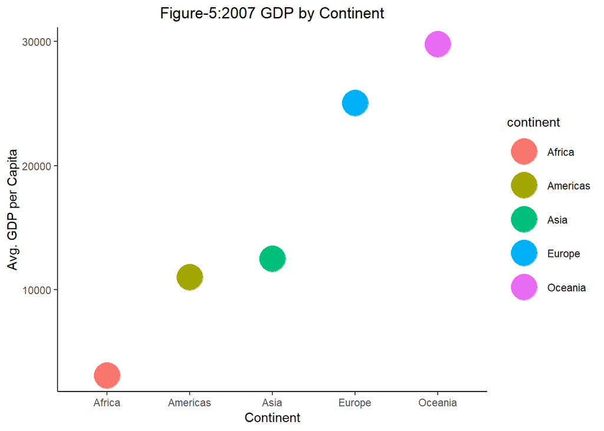

```r
GDPbyCont <- gapminder %>%
  filter(year==2007) %>%
  group_by(continent) %>%
  summarize(avgGDP = mean(gdpPercap))
ggplot(GDPbyCont,
  aes(x = continent, y = avgGDP, color = continent)) +
  geom_point(size=10) +
  ggtitle("Figure-5:2007 GDP by Continent") +
  xlab("Continent") + ylab("Avg. GDP per Capita") +
  theme_classic() +
  theme(plot.title = element_text(hjust = 0.5))
```

### Research Question 4: What are the top 5 countries with largest GDP per capita in 2007?

#### Table-1

```r
gapminder %>% filter(year==2007) %>%
  arrange(-gdpPercap) %>%
  top_n(5)
```

```
## # A tibble: 5 x 8
##   country  continent  year lifeExp    pop gdpPercap lifeExpcat gdpPercaplog
##   <fct>    <fct>     <int>   <dbl>  <int>     <dbl> <fct>             <dbl>
## 1 Norway   Europe     2007    80.2 4.63e6    49357. (76.7,82.~         10.8
## 2 Kuwait   Asia       2007    77.6 2.51e6    47307. (76.7,82.~         10.8
## 3 Singapo~ Asia       2007    80.0 4.55e6    47143. (76.7,82.~         10.8
## 4 United ~ Americas   2007    78.2 3.01e8    42952. (76.7,82.~         10.7
## 5 Ireland  Europe     2007    78.9 4.11e6    40676. (76.7,82.~         10.6
```

#### Table-2

```r
gapminder %>% filter(year==2007) %>%
  arrange(-lifeExp) %>%
  top_n(5)
```

```
## # A tibble: 5 x 8
##   country  continent  year lifeExp    pop gdpPercap lifeExpcat gdpPercaplog
##   <fct>    <fct>     <int>   <dbl>  <int>     <dbl> <fct>             <dbl>
## 1 Norway   Europe     2007    80.2 4.63e6    49357. (76.7,82.~         10.8
## 2 Singapo~ Asia       2007    80.0 4.55e6    47143. (76.7,82.~         10.8
## 3 Ireland  Europe     2007    78.9 4.11e6    40676. (76.7,82.~         10.6
## 4 United ~ Americas   2007    78.2 3.01e8    42952. (76.7,82.~         10.7
## 5 Kuwait   Asia       2007    77.6 2.51e6    47307. (76.7,82.~         10.8
```

### Cluster analysis:

## Research Question 6: What is grouping in data for 2007?

### processing the data

```r
kmeansdata <- subset(gapminder,year == 2007, select = c("lifeExp","gdpPercap","pop", "country", "continent"))
summary(kmeansdata)
```

```
##     lifeExp        gdpPercap            pop                   country
##  Min.   :39.61   Min.   :  277.6   Min.   :1.996e+05   Afghanistan:  1
##  1st Qu.:57.16   1st Qu.: 1624.8   1st Qu.:4.508e+06   Albania    :  1
##  Median :71.94   Median : 6124.4   Median :1.052e+07   Algeria    :  1
##  Mean   :67.01   Mean   :11680.1   Mean   :4.402e+07   Angola     :  1
##  3rd Qu.:76.41   3rd Qu.:18008.8   3rd Qu.:3.121e+07   Argentina  :  1
##  Max.   :82.60   Max.   :49357.2   Max.   :1.319e+09   Australia  :  1
##                                                        (Other)    :136
##     continent
##  Africa  :52
##  Americas:25
##  Asia    :33
##  Europe  :30
##  Oceania : 2
##
##
```

```r
kmeansdata_scaled <- scale(kmeansdata[,1:3])
```

### Finding the best number of clusters

```r
library(factoextra)
```

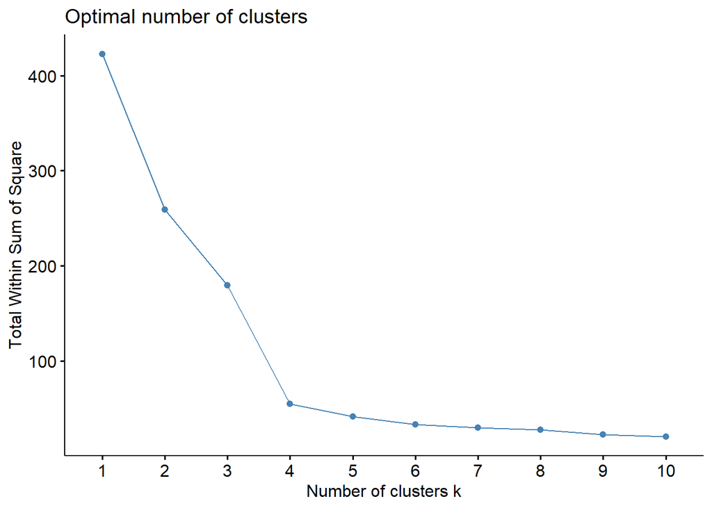

```r
fviz_nbclust(kmeansdata_scaled,kmeans,method = "wss")
```

### Building the model and exploring an output

```r
set.seed(1)
kmeansObj <- kmeans(kmeansdata_scaled, centers=4)
kmeansObj
```

```
## K-means clustering with 4 clusters of sizes 34, 46, 60, 2
##
## Cluster means:
##      lifeExp  gdpPercap         pop
## 1  1.0185244  1.6029084 -0.09445738
## 2 -1.2895686 -0.7215719 -0.16903041
## 3  0.4064747 -0.3344397 -0.08119059
## 4  0.1509214 -0.6200970  7.92919259
##
## Clustering vector:
##   [1] 2 3 3 2 3 1 1 1 3 1 2 3 3 2 3 3 2 2 2 2 1 2 2 3 4 3 3 2 2 3 2 3 3 1 1
##  [36] 2 3 3 3 3 2 2 2 1 1 2 2 1 2 1 3 2 2 2 3 1 3 1 4 3 3 2 1 1 1 3 1 3 2 3
##  [71] 1 1 3 2 2 3 2 2 3 2 3 3 3 3 3 3 2 2 2 3 1 1 3 2 2 1 1 3 3 3 3 3 3 1 1
## [106] 3 3 2 3 1 3 3 2 1 3 1 2 2 1 3 2 2 1 1 3 1 2 3 2 3 3 3 2 1 1 3 3 3 3 3
## [141] 2 2
##
## Within cluster sum of squares by cluster:
## [1] 17.640393 15.773511 20.065166  1.248608
##  (between_SS / total_SS =  87.1 %)
##
## Available components:
##
## [1] "cluster"      "centers"      "totss"        "withinss"
## [5] "tot.withinss" "betweenss"    "size"         "iter"
## [9] "ifault"
```

```r
kmeansdata$cluster <- kmeansObj$cluster
table(kmeansObj$cluster)
```

```
##
##  1  2  3  4
## 34 46 60  2
```

```r
print.data.frame(kmeansdata[,c("cluster", "country", "continent")])
```

```
##     cluster                  country continent
## 1         2              Afghanistan      Asia
## 2         3                  Albania    Europe
## 3         3                  Algeria    Africa
## 4         2                   Angola    Africa
## 5         3                Argentina  Americas
## 6         1                Australia   Oceania
## 7         1                  Austria    Europe
## 8         1                  Bahrain      Asia
## 9         3               Bangladesh      Asia
## 10        1                  Belgium    Europe
## 11        2                    Benin    Africa
## 12        3                  Bolivia  Americas
## 13        3   Bosnia and Herzegovina    Europe
## 14        2                 Botswana    Africa
```

[output cut: 128 more lines]

### Visualizing the clusters

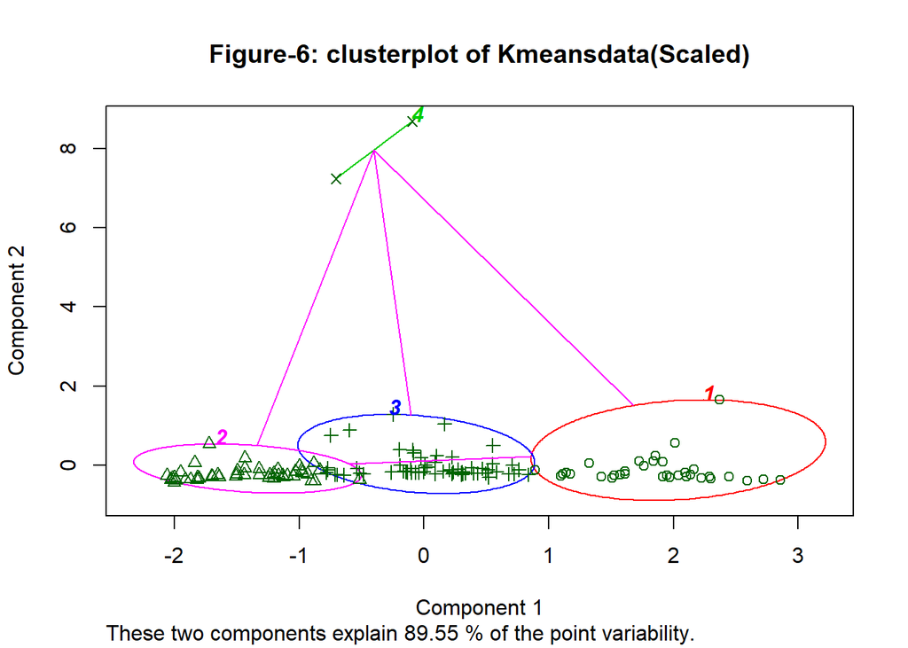

```r
clusplot(kmeansdata_scaled,kmeansObj$cluster, main = "Figure-6: clusterplot of Kmeansdata(Scaled)", labels = 4, color = 1)
```

### Research Question 7: What is life expectancy relation to all years and gdp?

### Multiple regression of all the data

```r
mreg1 <- lm(lifeExp~year+gdpPercaplog,data = gapminder)
summary(mreg1)
```

```
##
## Call:
## lm(formula = lifeExp ~ year + gdpPercaplog, data = gapminder)
##
## Residuals:
##      Min       1Q   Median       3Q      Max
## -27.2291  -3.8454   0.6065   4.7737  17.8644
##
## Coefficients:
##                Estimate Std. Error t value Pr(>|t|)
## (Intercept)  -3.911e+02  1.942e+01  -20.14   <2e-16 ***
## year          1.956e-01  9.927e-03   19.70   <2e-16 ***
## gdpPercaplog  7.770e+00  1.381e-01   56.27   <2e-16 ***
## ---
## Signif. codes:  0 '***' 0.001 '**' 0.01 '*' 0.05 '.' 0.1 ' ' 1
##
## Residual standard error: 6.877 on 1701 degrees of freedom
## Multiple R-squared:  0.7169, Adjusted R-squared:  0.7165
## F-statistic:  2153 on 2 and 1701 DF,  p-value: < 2.2e-16
```

### Checking models assumptions

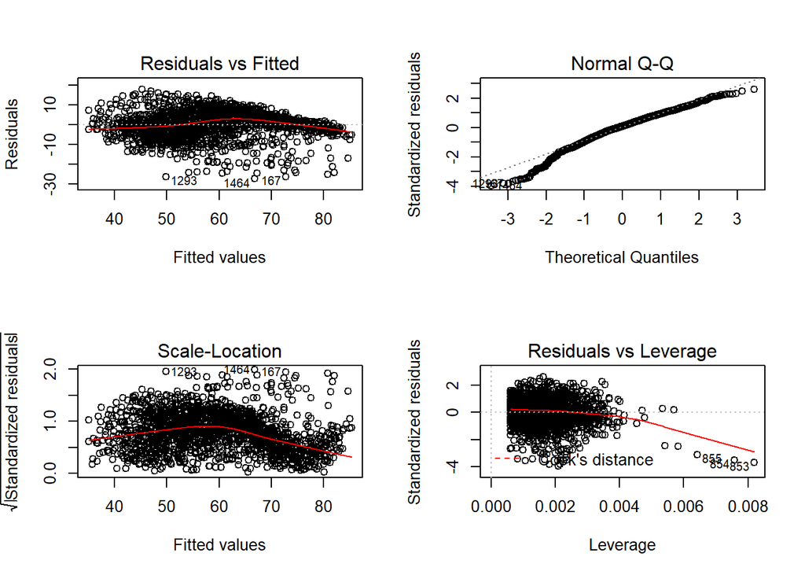

```r
par(mfrow = c(2,2))
plot(mreg1)
```

## Results and Conclusion:

Figure-1 shows most couries have lower GDP.Figure-2 demonstrats log transformation effectively normalizes the data.

### Research Question 2: What is life expectancy of different continent?

Figure-4 provides a boxplot of life expectancy of different continent. The figure shows Africa has th lowest life expectancy and Oceania and Europe have the highest life expectancy.

### Research Question 3:. What is the GDP distribution for different continents in 2007?

Figure-5 shows the average GDP distribution for different conitnents in 2007. The figure demonstrates Africa has the lowest GDP and Occean and Europ have the highest GDP Per Capita in 2007.

### Research Question 4: What are the top 5 countries with largest GDP per capita in 2007?

Table-1 shows Norway, Kuwait, Singapore, United States, and Ireland are the top 5 countries with largest GDP per capita in 2007.

### Research Question 6: What is grouping in data for 2007?

Figure-6 shows 4 different cluster of kmeansdata. In addition, figure-6 shows China(#4) and India (#4) are strongly separated from other grouping.

### Research Question 7: What is life expectancy relation to all years and gdp?

Regression analysis shows that life expectancy was significantly positively related to both year and gdp. The model fits was strong within R square of 0.72. Residual dignostics showed there are some problems with model assumptions.